# Monitoria 7

Sinara

2024-04-26

1. Teorema 6.1: Lei Fraca dos Grandes Números

À medida que o tamanho da amostra n aumenta, a probabilidade de a média das variáveis aleatórias estar próxima da média verdadeira se aproxima de 1. O estimador que converge em probabilidade é chamado de *consistente*.(Vem da teoria assintótica).

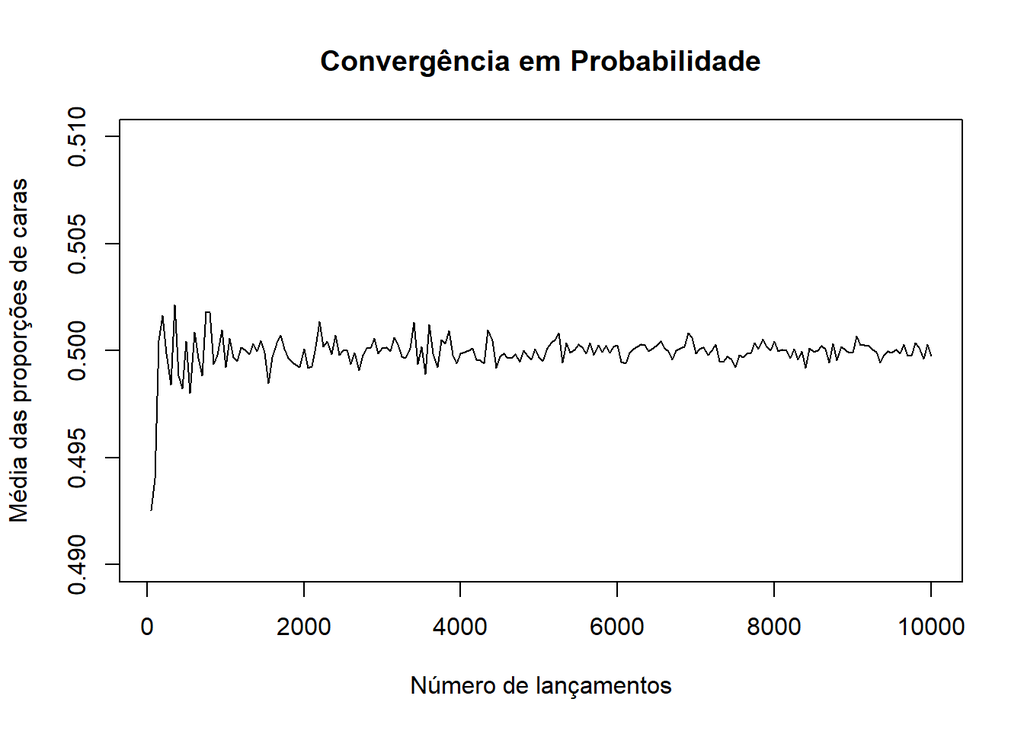

```r
# Função para simular lançamentos de uma moeda
simular_lancamentos_moeda <- function(n, p) {
  lancamentos <- rbinom(n, 1, p) # n lançamentos com probabilidade p de cara
  return(mean(lancamentos)) # proporção de caras
}

# Parâmetros
set.seed(123)
n_lancamentos <- seq(50, 10000, by = 50)  # lançamentos em cada série
prob_verdadeira <- 0.5  # Probabilidade verdadeira de cara da moeda
n_replicacoes <- 300  # Número de replicatas

# Simulação de uma série de lançamentos para cada número de lançamentos
medias <- sapply(n_lancamentos, function(n) replicate(n_replicacoes, simular_lancamentos_moeda(n, prob_verdadeira)))

# Plotar resultados
plot(n_lancamentos, colMeans(medias), type = 'l', ylim = c(0.49, 0.51),
     xlab = 'Número de lançamentos', ylab = 'Média das proporções de caras',
     main = 'Convergência em Probabilidade')
```

2. Teorema 6.2: Multivariate Lindeberg-Lévy Central Limit Theorem (CLT)

A distribuição limite da soma padronizada de variáveis aleatórias multivariadas independentes e identicamente distribuídas converge para uma distribuição normal multivariada N(0,V), desde que as variáveis aleatórias tenham momentos finitos de ordem suficientemente alta e os efeitos de dependência entre as variáveis aleatórias diminuam à medida que n aumenta.

```r
# Parâmetros
set.seed(123)
n <- 8000  # Tamanho da amostra
d <- 2  # Número de dimensões
mu <- rep(0, d)  # Média das variáveis aleatórias
Sigma <- matrix(c(1, 0.8, 0.8, 1), nrow = d, ncol = d)  # Matriz de covariância
n_replicatas <- 100  # Número de replicatas

# Função para gerar amostras multivariadas
gerar_amostra_multivariada <- function(n, mu, Sigma) {
  return(mvtnorm::rmvnorm(n, mean = mu, sigma = Sigma))
}

# Simulação do Multivariado Lindeberg-Lévy (CLT)
library(mvtnorm)
```

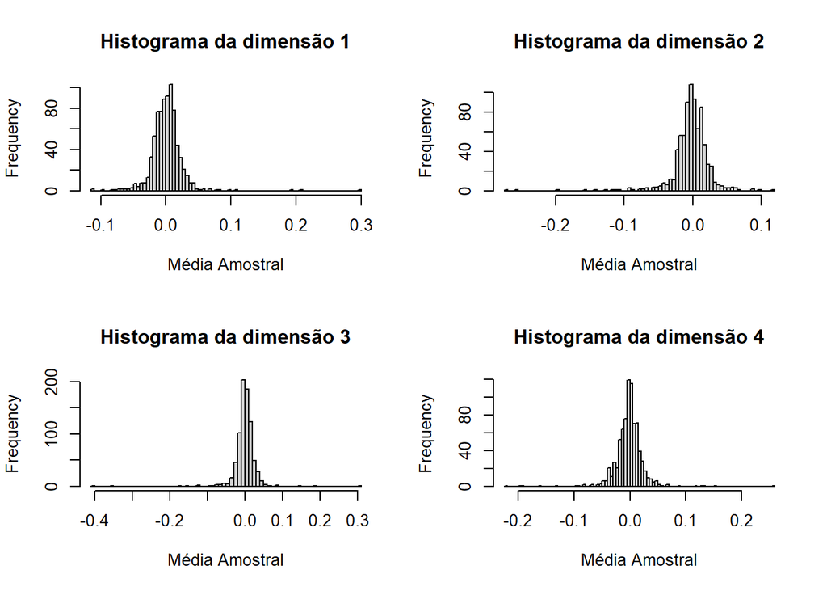

```r
medias <- sapply(seq(10, n, by = 10), function(m) {
  replicate(n_replicatas, {
    amostra <- gerar_amostra_multivariada(m, mu, Sigma)
    mean(amostra)
  })
})

# Plotagem dos resultados
par(mfrow = c(2, 2))
for (i in 1:4) {
  hist(medias[i,], main = paste("Histograma da dimensão", i), xlab = "Média Amostral", breaks = 80)
}
```

3. Dados em painel

Os dados em painel proporcionam mais informações, mais variabilidade, menos colinearidade entre as variáveis, mais graus de liberdade e mais eficiência, sendo mais adequados para estudar a dinâmica da mudança.